# EJERCICIO 3.

Fuente de los datos: https://www.kaggle.com/unsdsn/world-happiness

El código que presentaré a continuación será, a grandes rasgos, un análisis del World Happiness Report. En primer lugar, es de especial relevancia mencionar que tendremos que fusionar 3 datasets, ya que tenemos uno para cada año, 2015, 2016 y 2017. Las variables que contienen cada uno de estos datasets son:

- Year: esta columna la añadiremos nosotros al abrir cada uno de los datasets ya que no está incluida inicialmente.
- Country: el país al que pertenece
- Region: la región a la que pertenece el país.
- Happiness Rank:
- Happiness Score: Media de la nota (1-10) otorgada por los entrevistados en cuanto a la felicidad. Es decir, la media de la respuesta, de 1 a 10, a la pregunta ¿cómo de feliz eres?
- Standard Error: el Standard Error de la happiness score. Esto nos podría ayudar a estimar la desigualdad de un país, ya que nos dice cómo de dispersas están las observaciones individuales, a las que no podemos acceder, y por lo tanto nos aporta una información mucho más valiosa que la media, quizás insuficiente ya que no nos dice cómo están distribuidos los Happiness Score de las personas dentro de un país.
- Economy (GDP Per capita): cómo el GDP Per capita contribuye al cálculo del Happiness Score. Esto, en definitiva, suponemos que es la beta de una regresión múltiple en la que tenemos como variable dependiente el Happiness Score; esto es la beta de la variable independiente “Economy”. Esto mismo se cumple para todas las variables en las que la descripción empieza con “cómo la variable (…) contribuye al cálculo de (…)”. Alternativamente, podría resultar ser una suma de todas estas variables, lo cual averiguaremos en el siguiente Markdown.
- Family: cómo la familia contribuye al cálculo del Happiness Score.
- Health (Life Expectancy): cómo la esperanza de vida contribuye al Happiness Score.
- Freedom: cómo la libertad contribuye al Happiness Score.
- Trust (Government Corruption): cómo la percepción de la corrupción contribuye al Happiness Score.
- Generosity: cómo la percepción de la generosidad contribuye al cálculo del Happiness Score.
- Dystopia Residual: Esta variable es de especial interés, y para analizarla con detenimiento tuvimos que recurrir a la página web: http://worldhappiness.report/faq/, en la que se especifica que Dystopia sería un país imaginario que tuviera a la gente menos feiz del mundo. El objetivo de la variable Dystopia Residual es tener un benchmark contra el que comparar favorablemente a todos los países (es la distancia que existe desde la felicidad media en cada país a la felicidad media en ese país imaginario llamado Dystopia).Esta última variable también se utiliza para el cálculo del Happiness Score; teóricamente cuanto mayor es esta variable, más lejos está el país de lo que sería poco deseable.

En el archivo 2016.csv podemos encontrarnos con otras dos variables que añadir al estudio, éstas son Lower Confidence Level y Higher Confidence Level; ésto nos facilita el trabajo ya que estas dos variabLes, en caso de necesitarlas, se las añadiremos a los otros dos datasets manualmente. Damos por hecho que utilizan un 95% de confianza para establecer estos LCL y UCL. Para el archivo 2017.csv ocurre algo parecido, ya que no tenemos tampoco el SE, lo que nos dan son el bigote de arriba y de abajo de los Whiskers de un boxplot.

Con el fin de hacer el análisis más entretenido, hemos introducido algunos NAs en las variables para jugar un poco más con ellas. Esto, evidentemente, empeorará la calidad de los datos (pese a imputarles luego valores en función de unos criterios), por lo tanto las conclusiones que se extraigan de este análisis tendrán esa limitación añadida. El resto del análisis y de los resultados obtenidos en el código se irán describiendo a lo largo de la práctica.

```r
library(readr)

df_2015 <-read_csv("2015.csv")
df_2016 <-  read_csv("2016.csv")
df_2017 <-  read_csv("2017.csv")
todos_lista <-  list(df_2015, df_2016, df_2017)




#vamos a cambiarles los nombres a las variables para que sea más fácil trabajar con ellas.

names(todos_lista[[1]]) <- c("Country", "Region", "Happ_rank", "Happ", "SE", "econ", "fam", "health", "freedom", "gov_trust", "generosity", "Dyst_resid")

names(todos_lista[[2]]) <-  c("Country", "Region", "Happ_rank", "Happ", "LCL", "UCL", "econ", "fam", "health", "freedom", "gov_trust", "generosity", "Dyst_resid")

names(todos_lista[[3]]) <- c("Country", "Happ_rank", "Happ", "WH", "WL", "econ", "fam", "health", "freedom", "generosity", "gov_trust", "Dyst_resid")

str(todos_lista)
```

```
## List of 3
##  $ :Classes 'tbl_df', 'tbl' and 'data.frame':    158 obs. of  12 variables:
##   ..$ Country   : chr [1:158] "Switzerland" "Iceland" "Denmark" "Norway" ...
##   ..$ Region    : chr [1:158] "Western Europe" "Western Europe" "Western Europe" "Western Europe" ...
##   ..$ Happ_rank : int [1:158] 1 2 3 4 5 6 7 8 9 10 ...
##   ..$ Happ      : num [1:158] 7.59 7.56 7.53 7.52 7.43 ...
##   ..$ SE        : num [1:158] 0.0341 0.0488 0.0333 0.0388 0.0355 ...
##   ..$ econ      : num [1:158] 1.4 1.3 1.33 1.46 1.33 ...
##   ..$ fam       : num [1:158] 1.35 1.4 1.36 1.33 1.32 ...
##   ..$ health    : num [1:158] 0.941 0.948 0.875 0.885 0.906 ...
##   ..$ freedom   : num [1:158] 0.666 0.629 0.649 0.67 0.633 ...
##   ..$ gov_trust : num [1:158] 0.42 0.141 0.484 0.365 0.33 ...
##   ..$ generosity: num [1:158] 0.297 0.436 0.341 0.347 0.458 ...
##   ..$ Dyst_resid: num [1:158] 2.52 2.7 2.49 2.47 2.45 ...
##   ..- attr(*, "spec")=List of 2
##   .. ..$ cols   :List of 12
##   .. .. ..$ Country                      : list()
##   .. .. .. ..- attr(*, "class")= chr [1:2] "collector_character" "collector"
##   .. .. ..$ Region                       : list()
##   .. .. .. ..- attr(*, "class")= chr [1:2] "collector_character" "collector"
##   .. .. ..$ Happiness Rank               : list()
##   .. .. .. ..- attr(*, "class")= chr [1:2] "collector_integer" "collector"
##   .. .. ..$ Happiness Score              : list()
##   .. .. .. ..- attr(*, "class")= chr [1:2] "collector_double" "collector"
##   .. .. ..$ Standard Error               : list()
##   .. .. .. ..- attr(*, "class")= chr [1:2] "collector_double" "collector"
##   .. .. ..$ Economy (GDP per Capita)     : list()
##   .. .. .. ..- attr(*, "class")= chr [1:2] "collector_double" "collector"
##   .. .. ..$ Family                       : list()
##   .. .. .. ..- attr(*, "class")= chr [1:2] "collector_double" "collector"
##   .. .. ..$ Health (Life Expectancy)     : list()
##   .. .. .. ..- attr(*, "class")= chr [1:2] "collector_double" "collector"
##   .. .. ..$ Freedom                      : list()
##   .. .. .. ..- attr(*, "class")= chr [1:2] "collector_double" "collector"
##   .. .. ..$ Trust (Government Corruption): list()
##   .. .. .. ..- attr(*, "class")= chr [1:2] "collector_double" "collector"
##   .. .. ..$ Generosity                   : list()
##   .. .. .. ..- attr(*, "class")= chr [1:2] "collector_double" "collector"
##   .. .. ..$ Dystopia Residual            : list()
##   .. .. .. ..- attr(*, "class")= chr [1:2] "collector_double" "collector"
```

[output cut: 75 more lines]

```
##   .. .. ..$ Family                       : list()
##   .. .. .. ..- attr(*, "class")= chr [1:2] "collector_double" "collector"
##   .. .. ..$ Health..Life.Expectancy.     : list()
##   .. .. .. ..- attr(*, "class")= chr [1:2] "collector_double" "collector"
##   .. .. ..$ Freedom                      : list()
##   .. .. .. ..- attr(*, "class")= chr [1:2] "collector_double" "collector"
##   .. .. ..$ Generosity                   : list()
##   .. .. .. ..- attr(*, "class")= chr [1:2] "collector_double" "collector"
##   .. .. ..$ Trust..Government.Corruption.: list()
##   .. .. .. ..- attr(*, "class")= chr [1:2] "collector_double" "collector"
##   .. .. ..$ Dystopia.Residual            : list()
##   .. .. .. ..- attr(*, "class")= chr [1:2] "collector_double" "collector"
##   .. ..$ default: list()
##   .. .. ..- attr(*, "class")= chr [1:2] "collector_guess" "collector"
##   .. ..- attr(*, "class")= chr "col_spec"
```

```r
add_index <- function(df) { #le añadimos un índice a cada uno de los df.

  df$index <- seq(1, nrow(df), 1)

  return(df)

}


todos_lista_2 <-lapply(todos_lista[1:3], add_index)

#str(todos_lista_2)
```

```r
introduce_random_NAs <- function(df, seed = 15, nas = 8, cols = c("Country", "Happ_rank", "fam", "Dyst_resid")) {

  df2 <-  df


  for (columna in cols) {

      set.seed(seed)

      r_index <- sample.int(nrow(df2), size = nas)

      df2[r_index, columna] <- NA

  }

  return(df2)

}

todos_lista_nas <- lapply(todos_lista_2[1:3], introduce_random_NAs)

sum(is.na(todos_lista_nas[[1]]))
```

```
## [1] 32
```

```r
sum(is.na(todos_lista_nas[[2]]))
```

```
## [1] 32
```

```r
sum(is.na(todos_lista_nas[[3]]))
```

```
## [1] 32
```

```r
#vemos que ya tenemos los NAs introducidos.
```

```r
rank(todos_lista_nas[[2]]$Happ)
```

```
##   [1] 157.0 156.0 155.0 154.0 153.0 152.0 151.0 150.0 149.0 148.0 147.0
##  [12] 146.0 145.0 144.0 143.0 142.0 141.0 140.0 139.0 138.0 137.0 136.0
##  [23] 135.0 134.0 133.0 132.0 131.0 130.0 129.0 128.0 127.0 126.0 125.0
##  [34] 123.5 123.5 122.0 121.0 120.0 119.0 118.0 117.0 116.0 115.0 114.0
##  [45] 113.0 112.0 111.0 110.0 109.0 108.0 107.0 106.0 105.0 104.0 103.0
##  [56] 102.0 100.5 100.5  99.0  98.0  97.0  96.0  95.0  94.0  93.0  92.0
##  [67]  91.0  90.0  89.0  88.0  87.0  86.0  85.0  84.0  83.0  82.0  81.0
##  [78]  80.0  79.0  78.0  77.0  76.0  75.0  74.0  73.0  72.0  71.0  70.0
##  [89]  69.0  68.0  67.0  66.0  65.0  64.0  63.0  62.0  61.0  60.0  59.0
## [100]  58.0  57.0  56.0  55.0  54.0  53.0  52.0  51.0  50.0  49.0  48.0
## [111]  47.0  46.0  45.0  44.0  43.0  42.0  41.0  40.0  39.0  38.0  37.0
## [122]  36.0  35.0  34.0  33.0  32.0  31.0  30.0  29.0  28.0  27.0  26.0
## [133]  25.0  24.0  23.0  22.0  21.0  20.0  19.0  18.0  17.0  16.0  15.0
## [144]  14.0  12.5  12.5  11.0  10.0   9.0   8.0   7.0   6.0   5.0   4.0
## [155]   3.0   2.0   1.0
```

```r
#vemos que están en orden inverso; esto nos ayudará a imputar los valores de Happiness_rank
```

```r
todos_lista_nas2 <- lapply(todos_lista_nas[1:3], data.frame) #transformamos todos a la clase data.frame (antes teníamos varias posibles clases que podía tomar, pero es más cómodo trabajar con data frames)
```

Este código que viene a continuación tiene como objetivo “arreglar” el problema que tenemos con el df de 2017, en el que no viene la variable Region, la cual necesitamos para agrupar a la hora de imputar valores a las variables a las que hemos itroducido NAs.

```r
library(dplyr)
df1 <- todos_lista_nas2[[1]]





df2 <-  todos_lista_nas[[2]]

grupos_region <- df2 %>%
  group_by(Region) %>%
  select(Country)
df3 <-  todos_lista_nas[[3]]



#ordenamos alfabéticamente ambos dataframes, tanto el del año 2017 como el de los grupos que nos creamos para poder imputar las regiones en el dataset del 2017.

ordered_df3 <- df3[order(df3$Country), ]

grupos_ordenados <-  grupos_region[order(grupos_region$Country), ]

grupos_df <-  data.frame(grupos_ordenados)

df3_bis <-  merge(ordered_df3, grupos_ordenados, by.x = "Country", by.y = "Country", all.x = T, all.y = F, incomparables = NA)




todos_lista_nas2[[3]] <-  NULL #primero eliminamos el df3 de la lista

todos_lista_nas2[[3]] <-  df3_bis #y posteriormente le introducimos el nuevo df que hemos creado en el que se incluyen las regiones.
```

```r
head(todos_lista_nas2[[3]]) #como podemos ver, aquí tenemos ya introducida la variable Region.
```

```
##       Country Happ_rank  Happ       WH       WL      econ       fam
## 1 Afghanistan       141 3.794 3.873661 3.714338 0.4014772 0.5815433
## 2     Albania       109 4.644 4.752464 4.535536 0.9961928 0.8036852
## 3     Algeria        53 5.872 5.978286 5.765714 1.0918645 1.1462175
## 4      Angola       140 3.795 3.951642 3.638358 0.8584282 1.1044120
## 5   Argentina        24 6.599 6.690085 6.507915 1.1852955 1.4404511
## 6     Armenia       121 4.376 4.466735 4.285265 0.9005967 1.0074837
##       health   freedom generosity  gov_trust Dyst_resid index
## 1 0.18074678 0.1061795 0.31187093 0.06115783   2.150801   141
## 2 0.73115975 0.3814986 0.20131294 0.03986422   1.490442   109
## 3 0.61758465 0.2333358 0.06943665 0.14609611   2.567604    53
## 4 0.04986867 0.0000000 0.09792649 0.06972034   1.614482   140
## 5 0.69513708 0.4945192 0.10945706 0.05973989   2.614005    24
## 6 0.63752443 0.1983033 0.08348809 0.02667442   1.521499   121
##                            Region
## 1                   Southern Asia
## 2      Central and Eastern Europe
## 3 Middle East and Northern Africa
## 4              Sub-Saharan Africa
## 5     Latin America and Caribbean
## 6      Central and Eastern Europe
```

Una vez hemos introducido los Nas, vamos a proceder a limpiarlos con otra función: fix_nas()

```r
library(dplyr)

means_by_region <-  function(df) {
  require(dplyr)
  df2 <- df %>%
    group_by(Region) %>%
    summarise(media_happ = mean(Happ, na.rm = T),
              media_fam = mean(fam, na.rm = T),
              mean_dyst_resid = mean(Dyst_resid, na.rm = T))

  return(data.frame(df2))
}

todos_na_groups <- lapply(todos_lista_nas2, means_by_region)
#posiblemente lleguemos a no tener que utilizar estas variables agrupadas, pero por si acaso las tenemos en esta lista, en caso de necesitarlas.
```

```r
fix_nas <- function(df, cols = c("Country", "Happ_rank", "fam", "Dyst_resid")) {

  index_reversed <- rev(df$index)

  for (columna in cols) {

    if (columna == "Country") {

      next

    } else if (columna == "Happ_rank") { #como esta columna depende directamente del Happiness Score, y los df están ordenados descendentemente según esta variable...

      df[ , columna] <- df$index

    } else if (columna == "fam") {


        d <-  df %>%
                    group_by(Region) %>%
                        mutate(fam = ifelse(is.na(fam), mean(fam, na.rm = T), fam)) %>%
                            select(fam) #utilizamos esto para imputar la media de la variable en caso de estar ausente. Haremos lo mismo con la columna Dyst_resid.

        df$fam <- d$fam


    } else if (columna == "Dyst_resid") {


          d   <-  df %>%
                          group_by(Region) %>%
                            mutate(Dyst_resid = ifelse(is.na(Dyst_resid), mean(Dyst_resid, na.rm = T), Dyst_resid)) %>%
                                select(Dyst_resid)

          df$Dyst_resid <- d$Dyst_resid


    } else {

      print("Check the columns you have introduced")

    }
  }

  return(df)

}
```

```r
lista_limpios <-  lapply(todos_lista_nas2, fix_nas)
sum(is.na(lista_limpios[[1]]))
```

```
## [1] 8
```

```r
sum(is.na(lista_limpios[[2]]))
```

```
## [1] 8
```

```r
sum(is.na(lista_limpios[[3]]))
```

```
## [1] 27
```

Como podemos ver, quedan los df limpios a excepción del país, que es un valor que no podemos imputar (no de forma tan sencilla, una opción sería diseñar una función que, viendo como se comporta cada país en cada año, es decir qué valores tienen sus variables cada año, tratara de averiguar el país más probable al que pertenecen las observaciones). Una excepción a esto es lo que ocurre con el df de 2017; esto se debe a que para imputarle la región, utilizamos los datos de 2016, y debido a cambios geopolíticos (o a simple ausencia de los datos; por ejemplo en el caso de Polonia, no teníamos datos para el año 2016, pero sí en el 2017; esto provoca que no se pueda incorporar su región al hacer el “merge”); se han creado países nuevos o fusionado algunos dejando un único país (esto era algo que ya habíamos intuido por la diferencia en el número de filas entre los dataframes). Esto provoca que en aquellos casos en los que no se ha podido encontrar la región a la que pertenece el país, se han imputado esos valores con NAs, con los cuales tendremos que trabajar a partir de ahora, ya que no disponemos de más información para poder imputar estos valores.

## ANÁLISIS

Ahora procederé a realizar un pequeño análisis de datos, tratando de responder a preguntas cómo: ¿Cuáles son las regiones del mundo con una mayor nota media en felicidad? ¿Y los que menos? ¿En qué regiones encontramos la mayor diferencia de felicidad entre unos países y otros? ¿Qué países tienen unas diferencias mayores en la felicidad de los habitantes?

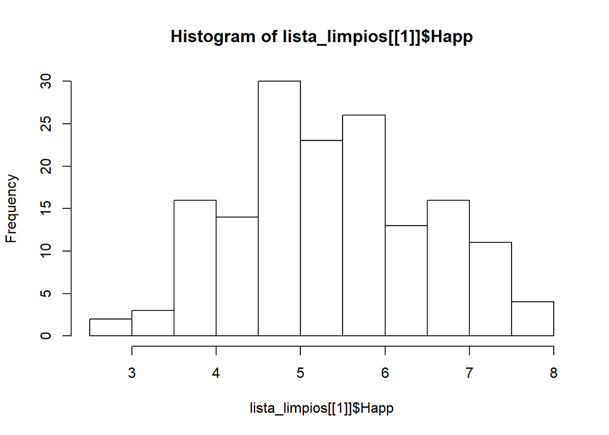

```r
#vamos a explorar un poco las variables.

n = round(sqrt(nrow(lista_limpios[[1]]))) #utilizamos la "rule of thumb" de que debemos utilizar breaks = sqrt(n), siendo n el número de observaciones que tenemos. Aunque el número de observaciones difiere de unos df a otros, siendo la diferencia tan pequeña utilizaremos el número de filas del dataset de 2015 para dibujar los 3 histogramas.

hist(lista_limpios[[1]]$Happ, breaks = n)
```

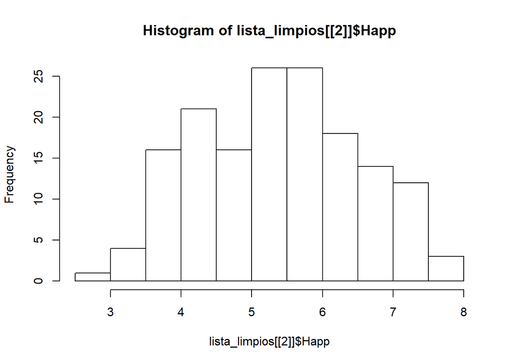

```r
hist(lista_limpios[[2]]$Happ, breaks = n)
```

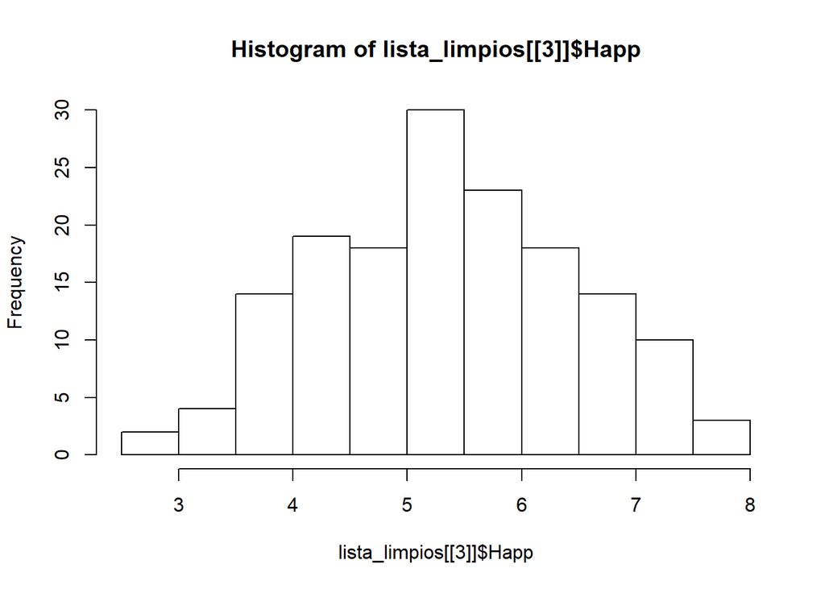

```r
hist(lista_limpios[[3]]$Happ, breaks = n)
```

En los 3 histogramas de arriba podemos ver cómo se distribuye la media por país de la felicidad (del 1 al 10), en cada uno de los 3 años (2015, 16 y 17 respectivamente). Vemos que la forma que toman estos histogramas, especialmente los de 2015 y 2017, es muy parecida a la normal de Gauss. Más adelante dibujaremos unos boxplot que nos puedan dar algo más de información sobre cómo se distribuye la variable happ en cada uno de los años, ya que en el histograma, al variar la escala del eje y de unos df a otros tenemos algunas dificultades para poder afirmar apreciaciones a simple vista.

```r
summary(lista_limpios[[1]])
```

```
##    Country             Region            Happ_rank           Happ
##  Length:158         Length:158         Min.   :  1.00   Min.   :2.839
##  Class :character   Class :character   1st Qu.: 40.25   1st Qu.:4.526
##  Mode  :character   Mode  :character   Median : 79.50   Median :5.232
##                                        Mean   : 79.50   Mean   :5.376
##                                        3rd Qu.:118.75   3rd Qu.:6.244
##                                        Max.   :158.00   Max.   :7.587
##        SE               econ             fam             health
##  Min.   :0.01848   Min.   :0.0000   Min.   :0.0000   Min.   :0.0000
##  1st Qu.:0.03727   1st Qu.:0.5458   1st Qu.:0.8137   1st Qu.:0.4392
##  Median :0.04394   Median :0.9102   Median :1.0257   Median :0.6967
##  Mean   :0.04788   Mean   :0.8461   Mean   :0.9867   Mean   :0.6303
##  3rd Qu.:0.05230   3rd Qu.:1.1584   3rd Qu.:1.2144   3rd Qu.:0.8110
##  Max.   :0.13693   Max.   :1.6904   Max.   :1.4022   Max.   :1.0252
##     freedom         gov_trust         generosity       Dyst_resid
##  Min.   :0.0000   Min.   :0.00000   Min.   :0.0000   Min.   :0.3286
##  1st Qu.:0.3283   1st Qu.:0.06168   1st Qu.:0.1506   1st Qu.:1.7874
##  Median :0.4355   Median :0.10722   Median :0.2161   Median :2.0475
##  Mean   :0.4286   Mean   :0.14342   Mean   :0.2373   Mean   :2.1011
##  3rd Qu.:0.5491   3rd Qu.:0.18025   3rd Qu.:0.3099   3rd Qu.:2.4532
##  Max.   :0.6697   Max.   :0.55191   Max.   :0.7959   Max.   :3.6021
##      index
##  Min.   :  1.00
##  1st Qu.: 40.25
##  Median : 79.50
##  Mean   : 79.50
##  3rd Qu.:118.75
##  Max.   :158.00
```

```r
summary(lista_limpios[[2]])
```

```
##    Country             Region            Happ_rank        Happ
##  Length:157         Length:157         Min.   :  1   Min.   :2.905
##  Class :character   Class :character   1st Qu.: 40   1st Qu.:4.404
##  Mode  :character   Mode  :character   Median : 79   Median :5.314
##                                        Mean   : 79   Mean   :5.382
##                                        3rd Qu.:118   3rd Qu.:6.269
##                                        Max.   :157   Max.   :7.526
##       LCL             UCL             econ             fam
##  Min.   :2.732   Min.   :3.078   Min.   :0.0000   Min.   :0.0000
##  1st Qu.:4.327   1st Qu.:4.465   1st Qu.:0.6702   1st Qu.:0.6418
##  Median :5.237   Median :5.419   Median :1.0278   Median :0.8478
##  Mean   :5.282   Mean   :5.482   Mean   :0.9539   Mean   :0.7941
##  3rd Qu.:6.154   3rd Qu.:6.434   3rd Qu.:1.2796   3rd Qu.:1.0051
##  Max.   :7.460   Max.   :7.669   Max.   :1.8243   Max.   :1.1833
##      health          freedom         gov_trust         generosity
##  Min.   :0.0000   Min.   :0.0000   Min.   :0.00000   Min.   :0.0000
##  1st Qu.:0.3829   1st Qu.:0.2575   1st Qu.:0.06126   1st Qu.:0.1546
##  Median :0.5966   Median :0.3975   Median :0.10547   Median :0.2225
##  Mean   :0.5576   Mean   :0.3710   Mean   :0.13762   Mean   :0.2426
##  3rd Qu.:0.7299   3rd Qu.:0.4845   3rd Qu.:0.17554   3rd Qu.:0.3119
##  Max.   :0.9528   Max.   :0.6085   Max.   :0.50521   Max.   :0.8197
##    Dyst_resid         index
##  Min.   :0.8179   Min.   :  1
##  1st Qu.:2.0317   1st Qu.: 40
##  Median :2.2907   Median : 79
##  Mean   :2.3251   Mean   : 79
##  3rd Qu.:2.6646   3rd Qu.:118
##  Max.   :3.8377   Max.   :157
```

```r
summary(lista_limpios[[3]])
```

```
##    Country            Happ_rank          Happ             WH
##  Length:155         Min.   :  1.0   Min.   :2.693   Min.   :2.865
##  Class :character   1st Qu.: 39.5   1st Qu.:4.505   1st Qu.:4.608
##  Mode  :character   Median : 78.0   Median :5.279   Median :5.370
##                     Mean   : 78.0   Mean   :5.354   Mean   :5.452
##                     3rd Qu.:116.5   3rd Qu.:6.101   3rd Qu.:6.195
##                     Max.   :155.0   Max.   :7.537   Max.   :7.622
##        WL             econ             fam            health
##  Min.   :2.521   Min.   :0.0000   Min.   :0.000   Min.   :0.0000
##  1st Qu.:4.375   1st Qu.:0.6634   1st Qu.:1.075   1st Qu.:0.3699
##  Median :5.193   Median :1.0646   Median :1.238   Median :0.6060
##  Mean   :5.256   Mean   :0.9847   Mean   :1.190   Mean   :0.5513
##  3rd Qu.:6.007   3rd Qu.:1.3180   3rd Qu.:1.414   3rd Qu.:0.7230
##  Max.   :7.480   Max.   :1.8708   Max.   :1.611   Max.   :0.9495
##     freedom         generosity       gov_trust         Dyst_resid
##  Min.   :0.0000   Min.   :0.0000   Min.   :0.00000   Min.   :0.3779
##  1st Qu.:0.3037   1st Qu.:0.1541   1st Qu.:0.05727   1st Qu.:1.6160
##  Median :0.4375   Median :0.2315   Median :0.08985   Median :1.8315
##  Mean   :0.4088   Mean   :0.2469   Mean   :0.12312   Mean   :1.8482
##  3rd Qu.:0.5166   3rd Qu.:0.3238   3rd Qu.:0.15330   3rd Qu.:2.1326
##  Max.   :0.6582   Max.   :0.8381   Max.   :0.46431   Max.   :3.1175
##      index          Region
##  Min.   :  1.0   Length:155
##  1st Qu.: 39.5   Class :character
##  Median : 78.0   Mode  :character
##  Mean   : 78.0
##  3rd Qu.:116.5
##  Max.   :155.0
```

```r
#aquí podemos ver una descripción general de los 3 dataframes; para poder obtener algo más de información, vamos a transformar la región a factor, de tal forma que podamos ver cuántos países hay en cada región.
```

```r
lista_limpios[[1]]$Region <- as.factor(lista_limpios[[1]]$Region)
lista_limpios[[2]]$Region <- as.factor(lista_limpios[[2]]$Region)
lista_limpios[[3]]$Region <- as.factor(lista_limpios[[3]]$Region)
```

```r
summary(lista_limpios[[1]])
```

```
##    Country                                      Region     Happ_rank
##  Length:158         Sub-Saharan Africa             :40   Min.   :  1.00
##  Class :character   Central and Eastern Europe     :29   1st Qu.: 40.25
##  Mode  :character   Latin America and Caribbean    :22   Median : 79.50
##                     Western Europe                 :21   Mean   : 79.50
##                     Middle East and Northern Africa:20   3rd Qu.:118.75
##                     Southeastern Asia              : 9   Max.   :158.00
##                     (Other)                        :17
##       Happ             SE               econ             fam
##  Min.   :2.839   Min.   :0.01848   Min.   :0.0000   Min.   :0.0000
##  1st Qu.:4.526   1st Qu.:0.03727   1st Qu.:0.5458   1st Qu.:0.8137
##  Median :5.232   Median :0.04394   Median :0.9102   Median :1.0257
##  Mean   :5.376   Mean   :0.04788   Mean   :0.8461   Mean   :0.9867
##  3rd Qu.:6.244   3rd Qu.:0.05230   3rd Qu.:1.1584   3rd Qu.:1.2144
##  Max.   :7.587   Max.   :0.13693   Max.   :1.6904   Max.   :1.4022
##
##      health          freedom         gov_trust         generosity
##  Min.   :0.0000   Min.   :0.0000   Min.   :0.00000   Min.   :0.0000
##  1st Qu.:0.4392   1st Qu.:0.3283   1st Qu.:0.06168   1st Qu.:0.1506
##  Median :0.6967   Median :0.4355   Median :0.10722   Median :0.2161
##  Mean   :0.6303   Mean   :0.4286   Mean   :0.14342   Mean   :0.2373
##  3rd Qu.:0.8110   3rd Qu.:0.5491   3rd Qu.:0.18025   3rd Qu.:0.3099
##  Max.   :1.0252   Max.   :0.6697   Max.   :0.55191   Max.   :0.7959
##
##    Dyst_resid         index
##  Min.   :0.3286   Min.   :  1.00
##  1st Qu.:1.7874   1st Qu.: 40.25
##  Median :2.0475   Median : 79.50
##  Mean   :2.1011   Mean   : 79.50
##  3rd Qu.:2.4532   3rd Qu.:118.75
##  Max.   :3.6021   Max.   :158.00
##
```

```r
summary(lista_limpios[[2]])
```

```
##    Country                                      Region     Happ_rank
##  Length:157         Sub-Saharan Africa             :38   Min.   :  1
##  Class :character   Central and Eastern Europe     :29   1st Qu.: 40
##  Mode  :character   Latin America and Caribbean    :24   Median : 79
##                     Western Europe                 :21   Mean   : 79
##                     Middle East and Northern Africa:19   3rd Qu.:118
##                     Southeastern Asia              : 9   Max.   :157
##                     (Other)                        :17
##       Happ            LCL             UCL             econ
##  Min.   :2.905   Min.   :2.732   Min.   :3.078   Min.   :0.0000
##  1st Qu.:4.404   1st Qu.:4.327   1st Qu.:4.465   1st Qu.:0.6702
##  Median :5.314   Median :5.237   Median :5.419   Median :1.0278
##  Mean   :5.382   Mean   :5.282   Mean   :5.482   Mean   :0.9539
##  3rd Qu.:6.269   3rd Qu.:6.154   3rd Qu.:6.434   3rd Qu.:1.2796
##  Max.   :7.526   Max.   :7.460   Max.   :7.669   Max.   :1.8243
##
##       fam             health          freedom         gov_trust
##  Min.   :0.0000   Min.   :0.0000   Min.   :0.0000   Min.   :0.00000
##  1st Qu.:0.6418   1st Qu.:0.3829   1st Qu.:0.2575   1st Qu.:0.06126
##  Median :0.8478   Median :0.5966   Median :0.3975   Median :0.10547
##  Mean   :0.7941   Mean   :0.5576   Mean   :0.3710   Mean   :0.13762
##  3rd Qu.:1.0051   3rd Qu.:0.7299   3rd Qu.:0.4845   3rd Qu.:0.17554
##  Max.   :1.1833   Max.   :0.9528   Max.   :0.6085   Max.   :0.50521
##
##    generosity       Dyst_resid         index
##  Min.   :0.0000   Min.   :0.8179   Min.   :  1
##  1st Qu.:0.1546   1st Qu.:2.0317   1st Qu.: 40
##  Median :0.2225   Median :2.2907   Median : 79
##  Mean   :0.2426   Mean   :2.3251   Mean   : 79
##  3rd Qu.:0.3119   3rd Qu.:2.6646   3rd Qu.:118
##  Max.   :0.8197   Max.   :3.8377   Max.   :157
##
```

```r
summary(lista_limpios[[3]])
```

```
##    Country            Happ_rank          Happ             WH
##  Length:155         Min.   :  1.0   Min.   :2.693   Min.   :2.865
##  Class :character   1st Qu.: 39.5   1st Qu.:4.505   1st Qu.:4.608
##  Mode  :character   Median : 78.0   Median :5.279   Median :5.370
##                     Mean   : 78.0   Mean   :5.354   Mean   :5.452
##                     3rd Qu.:116.5   3rd Qu.:6.101   3rd Qu.:6.195
##                     Max.   :155.0   Max.   :7.537   Max.   :7.622
##
##        WL             econ             fam            health
##  Min.   :2.521   Min.   :0.0000   Min.   :0.000   Min.   :0.0000
##  1st Qu.:4.375   1st Qu.:0.6634   1st Qu.:1.075   1st Qu.:0.3699
##  Median :5.193   Median :1.0646   Median :1.238   Median :0.6060
##  Mean   :5.256   Mean   :0.9847   Mean   :1.190   Mean   :0.5513
##  3rd Qu.:6.007   3rd Qu.:1.3180   3rd Qu.:1.414   3rd Qu.:0.7230
##  Max.   :7.480   Max.   :1.8708   Max.   :1.611   Max.   :0.9495
##
##     freedom         generosity       gov_trust         Dyst_resid
##  Min.   :0.0000   Min.   :0.0000   Min.   :0.00000   Min.   :0.3779
##  1st Qu.:0.3037   1st Qu.:0.1541   1st Qu.:0.05727   1st Qu.:1.6160
##  Median :0.4375   Median :0.2315   Median :0.08985   Median :1.8315
##  Mean   :0.4088   Mean   :0.2469   Mean   :0.12312   Mean   :1.8482
##  3rd Qu.:0.5166   3rd Qu.:0.3238   3rd Qu.:0.15330   3rd Qu.:2.1326
##  Max.   :0.6582   Max.   :0.8381   Max.   :0.46431   Max.   :3.1175
##
##      index                                   Region
##  Min.   :  1.0   Sub-Saharan Africa             :33
##  1st Qu.: 39.5   Central and Eastern Europe     :26
##  Median : 78.0   Western Europe                 :20
##  Mean   : 78.0   Latin America and Caribbean    :19
##  3rd Qu.:116.5   Middle East and Northern Africa:19
##  Max.   :155.0   (Other)                        :19
##                  NA's                           :19
```

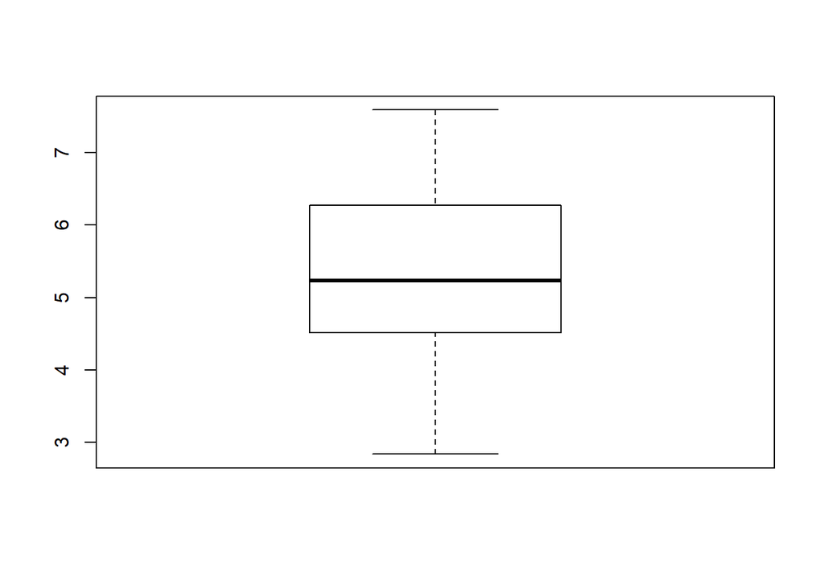

```r
boxplot(lista_limpios[[1]]$Happ)
```

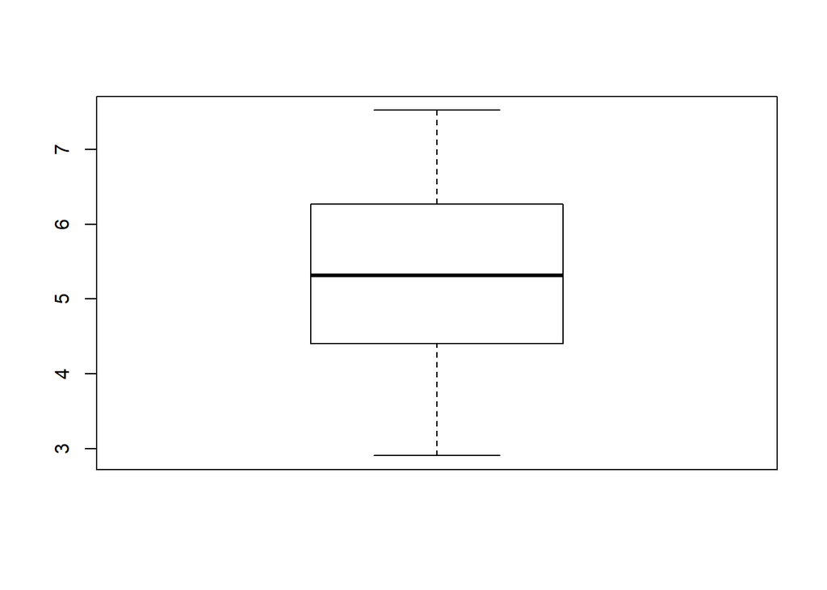

```r
boxplot(lista_limpios[[2]]$Happ)
```

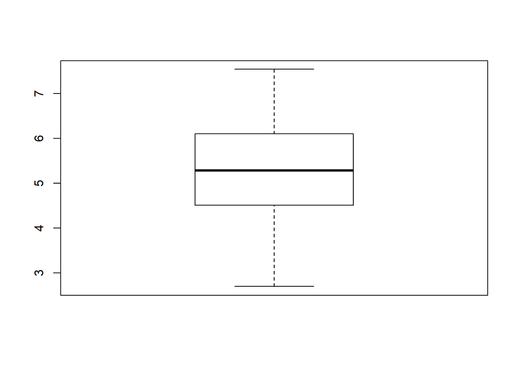

```r
boxplot(lista_limpios[[3]]$Happ)
```

Vemos que la mediana se sitúa algo por encima del 5, más cerca del Q1 que del Q3, para el año 2015. Para el año 2016, tenemos una distribución más simétrica para esta variable (happ), ya que la mediana se sitúa algo por encima que en el año 2015 (la diferencia es pequeña), sin embargo existe una distancia casi igual de la mediana a cada uno de los cuartiles Q1 y Q3. En el año 2017, algo que llama la atención es que el Q1 y el Q3 se encuentran más pegados que en los dos años anteriores, indicando una mayor concentración de los datos al rededor de la mediana de la distribución. Esto podría interpretarse como que existe, en el 2017, una menor diferencia en la felicidad entre unos países y otros. Sin embargo, y dado que tenemos menos datos en este año, estas diferencias podrían ser debidas a la carencia de información.

Para el análisis que viene a continuación, y con el fin de mantener la extensión de este razonable, nos centraremos principalmente en el df del que tenemos más datos, es decir el del año 2015.

```r
lista_limpios[[1]] %>%
  group_by(Region) %>%
  summarise(media_felicidad = mean(Happ, na.rm = T)) %>%
  arrange(desc(media_felicidad))
```

```
## # A tibble: 10 x 2
##    Region                          media_felicidad
##    <fct>                                     <dbl>
##  1 Australia and New Zealand                  7.28
##  2 North America                              7.27
##  3 Western Europe                             6.69
##  4 Latin America and Caribbean                6.14
##  5 Eastern Asia                               5.63
##  6 Middle East and Northern Africa            5.41
##  7 Central and Eastern Europe                 5.33
##  8 Southeastern Asia                          5.32
##  9 Southern Asia                              4.58
## 10 Sub-Saharan Africa                         4.20
```

Curiosamente, vemos que en el año 2015 los países de media más felices son aquellos que pertenecen a Australia y Nueva Zelanda, seguidos de North America y Western Europe. Una interpretación que se puede extraer de este análisis es que los países con un nivel de vida más alto tienen un mayor índice de felicidad; sin embargo hay algunas excepciones, ya que en Latin America & Caribbean, que en teoría existe un nivel de vida inferior al de Central & Eastern Europe, la gente es más feliz. Esto se podría explicar, entre casi infinitos motivos, por el clima.

Veamos si para el año 2017 esto ha cambiado o continúa igual:

```r
lista_limpios[[3]] %>%
  group_by(Region) %>%
  summarise(media_felicidad = mean(Happ, na.rm = T)) %>%
  arrange(desc(media_felicidad))
```

```
## # A tibble: 11 x 2
##    Region                          media_felicidad
##    <fct>                                     <dbl>
##  1 Australia and New Zealand                  7.30
##  2 North America                              7.15
##  3 Western Europe                             6.72
##  4 Latin America and Caribbean                5.90
##  5 Eastern Asia                               5.68
##  6 Southeastern Asia                          5.50
##  7 Central and Eastern Europe                 5.38
##  8 Middle East and Northern Africa            5.37
##  9 <NA>                                       5.04
## 10 Southern Asia                              4.62
## 11 Sub-Saharan Africa                         4.19
```

Nos interesa saber cuáles son las regiones que perciben una menor libertad:

```r
lista_limpios[[1]] %>%

  group_by(Region) %>%

  summarise(media_aportacion_libertad = mean(freedom)) %>%

  arrange(media_aportacion_libertad)
```

```
## # A tibble: 10 x 2
##    Region                          media_aportacion_libertad
##    <fct>                                               <dbl>
##  1 Central and Eastern Europe                          0.358
##  2 Middle East and Northern Africa                     0.362
##  3 Sub-Saharan Africa                                  0.366
##  4 Southern Asia                                       0.373
##  5 Eastern Asia                                        0.462
##  6 Latin America and Caribbean                         0.502
##  7 Western Europe                                      0.550
##  8 Southeastern Asia                                   0.557
##  9 North America                                       0.590
## 10 Australia and New Zealand                           0.645
```

Los países en los que se percibe que la libertad aporta menos al cálculo de la felicidad media del país son aquellos que pertenecen a Central & Eastern Europe, Middle East & Northern Africa y Sub-Saharan Africa.

Otra cuestión de interés, será saber en qué países la economía tiene un mayor peso a la hora de calcular la felicidad media.

```r
lista_limpios[[1]] %>%

  group_by(Region) %>%

  summarise(media_econ = mean(econ, na.rm= T)) %>%

  arrange(desc(media_econ))
```

```
## # A tibble: 10 x 2
##    Region                          media_econ
##    <fct>                                <dbl>
##  1 North America                        1.36
##  2 Western Europe                       1.30
##  3 Australia and New Zealand            1.29
##  4 Eastern Asia                         1.15
##  5 Middle East and Northern Africa      1.07
##  6 Central and Eastern Europe           0.942
##  7 Latin America and Caribbean          0.877
##  8 Southeastern Asia                    0.789
##  9 Southern Asia                        0.560
## 10 Sub-Saharan Africa                   0.380
```

Vemos que en los países más capitalistas (especialmente North America), el PIB per capita del país tiene un gran peso a la hora de calcular la media de la felicidad de la gente. A North America le siguen Western Europe y Australia-New Zealand.

Ahora vamos a ver en qué regiones encontramos una mayor disparidad en la felicidad media de los países:

```r
lista_limpios[[1]] %>%

  group_by(Region) %>%

  summarise(disparidad_felicidad = max(Happ, na.rm = T) - min(Happ, na.rm = T)) %>%

  arrange(desc(disparidad_felicidad))
```

```
## # A tibble: 10 x 2
##    Region                          disparidad_felicidad
##    <fct>                                          <dbl>
##  1 Middle East and Northern Africa              4.27
##  2 Southeastern Asia                            2.98
##  3 Western Europe                               2.73
##  4 Latin America and Caribbean                  2.71
##  5 Sub-Saharan Africa                           2.64
##  6 Central and Eastern Europe                   2.29
##  7 Southern Asia                                1.68
##  8 Eastern Asia                                 1.42
##  9 North America                                0.308
## 10 Australia and New Zealand                    0.00200
```

Estos resultados son tremendamente reveladores, ya que vemos que en primera posición se encuentran Middle East & Northern Africa, con una disparidad en la media de la felicidad entre los países que forman esta región de: ¡4.27!. Esta es una diferencia tremenda, especialmente si la comparamos, por ejemplo, con la diferencia que existe en Western Europe (2.73). Debemos recordar que no todas las regiones tienen el mismo número de países y esto, por supuesto, afecta a esta diferencia máxima en la felicidad de los países que forman las regiones. Sin embargo, sigue siendo destacable que esta disparidad entre Middle East & Northern Africa y Western Europe sea de 1.54; es una distancia tremenda que nos muestra la increíble disparidad que existe en Middle East & Northern Africa entre unos países y otros. No debemos olvidar tampoco que en este momento histórico (y aún más si cabe en 2015), muchos de los países que forman esta región están en guerra, y los que no lo están se ven afectados por la guerra de sus países vecinos. Esta observación puede ayudarnos a entender el por qué de esta gran diferencia.

Un indicador de las diferencias, de persona a persona dentro de un mismo país, en cuanto a la felicidad, nos la aporta el SE.

```r
lista_limpios[[1]] %>%
  arrange(desc(SE))
```

```
##                      Country                          Region Happ_rank
## 1                    Jamaica     Latin America and Caribbean        65
## 2                    Liberia              Sub-Saharan Africa       116
## 3        Trinidad and Tobago     Latin America and Caribbean        41
## 4                   Suriname     Latin America and Caribbean        40
## 5                    Lesotho              Sub-Saharan Africa        97
## 6                       <NA>              Sub-Saharan Africa       101
## 7                    Burundi              Sub-Saharan Africa       157
## 8                   Djibouti              Sub-Saharan Africa       126
## 9                 Mozambique              Sub-Saharan Africa        94
## 10                     Libya Middle East and Northern Africa        63
## 11        Dominican Republic     Latin America and Caribbean        98
## 12                     Haiti     Latin America and Caribbean       119
## 13                 Mauritius              Sub-Saharan Africa        71
## 14              Sierra Leone              Sub-Saharan Africa       123
```

[output cut: 462 more lines]

Por países, vemos que aquellos en los que la gente de un mismo país dio notas más dispares a su felicidad fue en Jamaica, Liberia y Trinidad & Tobago. Podríamos decir, por tanto, que estos son los países con una mayor desigualdad, con una mayor diferencia de felicidad de unas personas a otras. Sería interesante ver si existe alguna relación entre esta diferencia y el régimen político existente en los países.

Haremos ahora lo mismo pero agrupando por región.

```r
lista_limpios[[1]] %>%

  group_by(Region) %>%

  summarise(media_SE = mean(SE, na.rm = T)) %>%

  arrange(desc(media_SE))
```

```
## # A tibble: 10 x 2
##    Region                          media_SE
##    <fct>                              <dbl>
##  1 Latin America and Caribbean       0.0611
##  2 Sub-Saharan Africa                0.0553
##  3 Middle East and Northern Africa   0.0463
##  4 Central and Eastern Europe        0.0452
##  5 Southeastern Asia                 0.0427
##  6 Western Europe                    0.0376
##  7 Australia and New Zealand         0.0373
##  8 Eastern Asia                      0.0372
##  9 North America                     0.0370
## 10 Southern Asia                     0.0322
```

Las regiones en las que la diferencia en felicidad de unas personas a otras es mayor son Latin America & Caribbean y Sub-Saharan Africa. Las que menos, North America y Southern Asia.

```r
lista_limpios[[1]] %>%

  group_by(Region) %>%

  summarise(media_gov = mean(gov_trust, na.rm = T)) %>%

  arrange(desc(media_gov))
```

```
## # A tibble: 10 x 2
##    Region                          media_gov
##    <fct>                               <dbl>
##  1 Australia and New Zealand          0.393
##  2 North America                      0.244
##  3 Western Europe                     0.231
##  4 Middle East and Northern Africa    0.182
##  5 Southeastern Asia                  0.151
##  6 Eastern Asia                       0.128
##  7 Sub-Saharan Africa                 0.124
##  8 Latin America and Caribbean        0.117
##  9 Southern Asia                      0.103
## 10 Central and Eastern Europe         0.0867
```

```r
lista_limpios[[3]] %>%

  group_by(Region) %>%

  summarise(media_gov = mean(gov_trust, na.rm = T)) %>%

  arrange(desc(media_gov))
```

```
## # A tibble: 11 x 2
##    Region                          media_gov
##    <fct>                               <dbl>
##  1 Australia and New Zealand          0.342
##  2 Western Europe                     0.221
##  3 North America                      0.212
##  4 Middle East and Northern Africa    0.149
##  5 Southeastern Asia                  0.133
##  6 Southern Asia                      0.111
##  7 Sub-Saharan Africa                 0.103
##  8 Latin America and Caribbean        0.0946
##  9 <NA>                               0.0847
## 10 Central and Eastern Europe         0.0838
## 11 Eastern Asia                       0.0833
```

En primer lugar, podemos ver que la media por región de la variable gov_trust, decrece, de forma general. Respecto al ranking, Australia & New Zealand se mantiene en primera posición (los países de esta región son aquellos en los que la variable gov_trust afecta más al cálculo de la felicidad media del país); sin embargo, en el año 2015 era North America la segunda región, y Western Europe la tercera. Estas dos regiones se cambian el puesto en el año 2017.